# Boosting

# About boosting

In both bagged trees and random forest models, multiple trees are built and their results are aggregated. Similar to bagged trees and random forests, a boosted tree model aggregates results from many trees. Unlike bagged trees and random forests, where trees are “grown” independently of one another, boosted models create trees in a sequence, so that subsequent trees work on the results of previous trees and try to correct previously misclassified cases.

General procedure:

1. Build a single classification tree from all the data (or a bootstrap sample, depending on the option chosen). This first tree is usually fairly simple, and not a very good classifier, just a little better than 50% correct.
2. There are a couple different ways for building the next tree. In this case, the Adaboost procedure weights misclassified cases from the first tree more heavily than correct cases, to focus on those cases for the next round.
3. Build another simple tree again, making use of case weights from the previous tree to try to improve performance on trickier cases. At the end, weight wrongly classified cases more heavily again.
4. Repeat this process until a set number of trees (iterations) is reached, by testing a few different values and seeing where the error rate plateaus.
5. As a final step, aggregate the classification results of all trees, with different weights assigned to each tree depending on how well it performed overall. In other words, the final outcome is a summation of weighted outcomes from all trees.

# Parameters to tune

Parameters that can be tuned include: the total number of trees (iterations) in the model, the complexity of individual trees (number of splits, or maximum depth), and the shrinkage parameter or weight applied to all trees to adjust the “learning rate”. The first and last parameters interact to some extent, as a shrinkage parameter that is too small means that a large number of trees is needed to fit the data appropriately, which will take more time to run. A shrinkage parameter that is too big will quickly overfit the data, so that the model doesn’t generalize to other data.

The plot below shows that fewer trees worked better than more trees; model accuracy did not improve beyond 10 trees or so. More complex trees with more depth also worked better than a simple stump. When the learning rate was set higher, beyond 0.25 or so, the number of trees no longer mattered.

**Technical notes**

**Technical notes for plot**: The accuracy is the average out-of-bag accuracy for 15 bootstrap samples, from a 5-fold 3-repeat cross-validation procedure. Shaded areas are +/- 1 SD. Case weights were incorporated.

**Technical notes for choice of package**: *ada( )* from package ‘ada’ and *boosting( )* from package ‘adabag’ are both based on *rpart( )* and would be more comparable to previous analyses that were also based on *rpart( )*. Unfortunately neither method allows case weights, so that nearly all cases are classified as “No”. Alternative methods are *mboost( )* and *blackboost( )* from package ‘mboost’, which do allow case weights. However, *mboost( )* uses “stumps”, or a single split on one predictor per tree, and maxdepth can’t be adjusted. *blackboost( )* allows tuning of maxdepth but individual trees are constructed using statistical tests to determine splits instead of using the Gini index as in previous *rpart*-based methods. So *blackboost( )* results aren’t directly comparable to those previous *rpart*-based results, but being able to incorporate case weights and tune maxdepth outweighed other considerations. I chose family=AdaExp() to use the original Adaboost algorithm (Freund & Schapire, 1996).

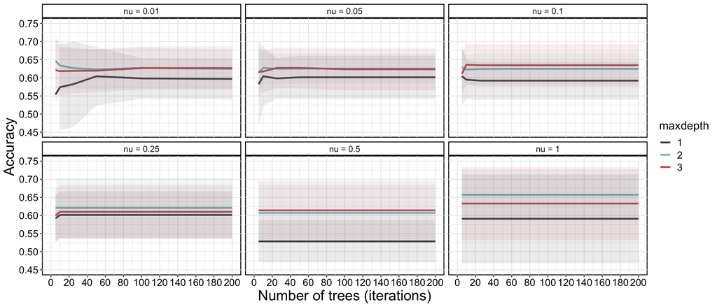

# Final model

```
##          actual
## predicted  No Yes
##       No  347  56
##       Yes 257  93
```

# Variable importance

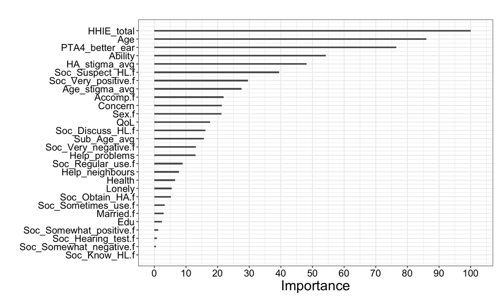

# Takeaways

[output not shown]

**Footnotes**:

**^^** It’s not really fair to compare the boosting results with the other tree methods’ results, as it used a different method to split cases.